# Simple Linear Regression

```r
# Load your libraries
library(car)
library(tidyverse)
library(mosaic)
library(pander)
library(ggplot2)
library(readr)
library(stringr)
library(DT)

steps2.sleep <- read.csv("../../LinearRegression_files/MyFitbitData/Steps_Sleep.csv")
steps2sleep <- steps2.sleep[-10,]
steps2sleep$Steps <- as.numeric(steps2sleep$Steps)
hours.asleep <- steps2sleep %>%
  mutate(Sleep.Hours = Minutes.Asleep / 60)

#view(hours.asleep)
#view(steps2.sleep)
#mean(hour.asleep$Steps)

# Load your data after saving a csv file in your Data folder.
# You can use either
#   someName <- read.csv("../Data/YourDataFileName.csv", header=TRUE)
# or
#   library(readr)
#   someName <- read_csv("../Data/YourDataFileName.csv")

# Don't forget to run "Session -> Set Working Directory -> To Source file location"
```

## Lindsie’s Steps Predict Her Sleep Pattern

```r
# To the Peer Reviewer:

# How do I center a graph on the page? I do not like it being left-centered.
# How do I center the title on the graph?
# Did I correctly use the right X and Y variable to run the lm?
# If I would like THIS very and only piece of R chunk to show up and not have to be clicked on to show the content, how do you that?
```

For months, my wife has been using a Fitbit watch to track her steps and sleep patterns. This has become part of her daily life. If it’s 10:30 p.m. and Lindsie has only 400 steps left to reach 10,000 steps then she will take the five minutes to jog in place and reach her 10,000 steps. After being married for a year, I would like to know if the number of steps Lindsie gets determines the amount of time she sleeps. My hypothesis is that the number of steps Lindsie takes will not impact her sleep pattern, but I would like to find out if that’s true or not.

## Analysis

### What You Want

#### Information from Linear Model

What I will model in the graph below is equationally represented in the following formula:

$$\underbrace{Y_i}_\text{Hours of Sleep} = \overbrace{\beta_0}^\text{y-int} + \overbrace{\beta_1}^\text{slope} \underbrace{X_i}_\text{Number of Steps} + \epsilon_i \quad \text{where} \ \epsilon_i \sim N(0, \sigma^2)$$

I am trying to measure here whether or not $\beta_1$ has any meaning. If $\beta_1$, or the slope, equates to $0$ then we cannot prove or even predict how many steps could be taken will show for the number of hours Lindsie may sleep. In other words:

$$H_0: \beta_1 = 0$$
$$H_a: \beta_1 \neq 0$$
$$\sigma = 0.05$$

As I thought too, we can observe without even seeing the numbers that our hypothesis may not be able to predict Lindsie’s sleep patterns by her step amount. Observe:

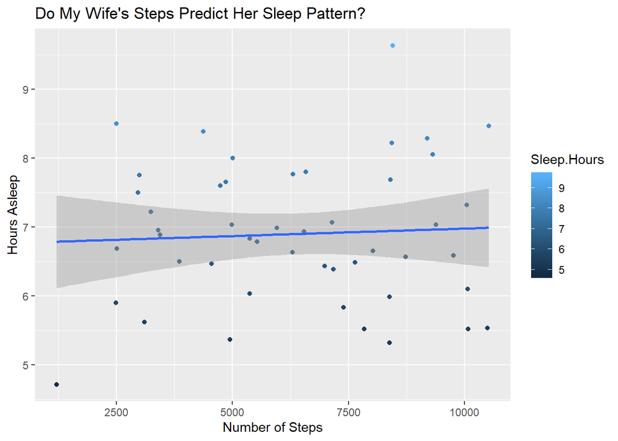

```r
#?mPlot
#mPlot(hours.asleep)
ggplot(data = hours.asleep, aes(x = Steps, y = Sleep.Hours)) +
  geom_point()  +
  aes(colour = Sleep.Hours) +
  stat_smooth(method = lm) +
  theme(legend.position = "right") +
  labs(title = "Do My Wife's Steps Predict Her Sleep Pattern?",
       x = "Number of Steps",
       y = "Hours Asleep")
```

The estimation of the regression above is given by

$$\underbrace{\hat{Y_i}}_\text{Avg. Hours of Sleep} = 6.761 + 2.162e-05 \underbrace{X_i}_\text{Number of Steps}$$

The estimated slope of this regression is 2.162e-05, which is not too different from zero, and gives us a fairly flat line. Additionally, when we look into the $p$-value of the the slope we see that it is `0.7122`. Thus we determine that $\beta_1$ is most likely zero because there is insignificant data to regret the null hypothesis. See the full entire regression summary below:

```r
hours.asleep.lm <- lm(Sleep.Hours ~ Steps, data = hours.asleep)
pander(summary(hours.asleep.lm))
```

|  | Estimate | Std. Error | t value | Pr(>\|t\|) |
| --- | --- | --- | --- | --- |
| **(Intercept)** | 6.761 | 0.3985 | 16.97 | 1.993e-21 |
| **Steps** | 2.162e-05 | 5.825e-05 | 0.3712 | 0.7122 |

Fitting linear model: Sleep.Hours ~ Steps

| Observations | Residual Std. Error | $R^2$ | Adjusted $R^2$ |
| --- | --- | --- | --- |
| 48 | 1.023 | 0.002987 | -0.01869 |